# Reproducible coding

Hyoungchul Kim

## Why reproducible coding?

- Empirical analysis is becoming more data-intensive and complex (big data, HPC computing, etc).
- It is difficult for researchers to manually track the analysis.
- What if you make a mistake that can fatally affect your main result? (e.g. Data pre-processing was wrong but cannot be reproduced)
- A Lot of top journals are incorporating code-editor these days.
- [AER example](https://retractionwatch.com/2023/07/18/econ-study-retracted-after-researchers-find-undocumented-alterations-in-the-code/)

## What do we need to learn?

Reproducible coding is not a single tool. It is a combination of multiple tools such as:

- Shell (Bash).
- Git.
- Project environment (renv, poetry, etc).
- Docker.
- Automation (Make, Snakemake).

We will briefly discuss these. You can learn more about them on your own after this.

## Setting up

From now on, we will be using shell (or terminal, bash, etc) a lot. Using a shell is a must for reproducible coding. In order to use this, the setup differs by the type of OS you are using.

### for Linux

Great choice! You are good to go.

### for Mac

Mostly okay. Install “homebrew” and you are good to go. But consider trying out linux using a 14-day free-trial of parallel desktop.

### for Windows

Tbh, some features are not going to work. Use WSL2 if you really want to use Windows. But I recommend you either use Mac or linux.

We don’t have time. So I am not going to tell you how to do this setup. DIY before the lecture.

# Shell (Bash)

## Shell

We will briefly follow the lecture note by Grant McDermott. But sth I want to emphasize:

1. Know the file system.
2. Know the CLI logic.
3. Why is shell helpful in reproducible coding?

## Basic definition

- Shell: A program that interprets your command and passes it onto your OS.
- Bash (Bourne Again SHell): A type of shell that is widely used.
- Terminal: Interface that allows users to type commands.

## Basic commands

```bash
ls [filename]
touch [filename]
mkdir [directory-name]
rm [filename]
rm -rf [directory-name]
mv [file-name] ../parent-directory/
mv [old-name] [new-name]
```

Checking your current directory and moving to other directory

```bash
pwd
cd directory
cd ..
cd .
cd ../..
```

Why is this useful?

```bash
# Making multiple files with similar names
touch car{1..1000}.txt

# removing multiple files with similar names
rm *.txt
```

## Write a shell script

Like a source code file in `R`, `Python`, we can also write a script for shell.

For example, we can write a file `run.sh`:

```bash
#!/bin/bash

echo "Hello, world."
```

## More

We can do lot more with bash. But I will stop for now. You can study more on your own. Bash will become our main playground from now on.

# Project environment

## Maintaining a closed environment

Have you ever experienced…

- My past code does not work because some packages I used got updated or changed.
- My coauthor cannot use my code because they have different version of the package that I used.
- Some packages that I used are no longer working because it used some other package (`depencencies`) which is now obsolete.

Solutions: Make a close environment where you can store and track all the versions and dependencies of the packages that you used.

## `Renv` package in R

In `R`, lot of ppl use `renv` package to do this.

### Setup

1. Create a `r-project.`
2. Install `renv` package and load it.

```r
# install it if you haven't
# install.packages("renv")

# load the package
library(renv)
```

3. `renv` will (most of the time) automatically check the list of packages (their versions and dependencies) you used in your project and will record them in `renv.lock` file.
4. `renv` will also create a folder named `renv` (of course). This is a folder where `renv` will store the packages you used in this project. (Instead of having a global library for packages, it creates separate space where you can store the packages you used in this project).

### Your `renv` workflow

0. Use `renv::init()` to create `renv` environment in your project.
1. Write down your code.
2. Time to time, use `renv::snapshot()` to update the `renv.lock` file. eg, if you install some new packages, it will be installed into your local library folder. If you use `renv::snapshot()`, the new package information will be recorded in the `renv.lock` file.
3. In the end, provide the renv folder and the `renv.lock` file to other ppl.

### Other’s `renv` workflow

1. Download your project and open up the r-project.
2. Assuming they have `renv` package, this is trigger `renv` package to restore the environment with the `renv.lock` file.
3. Other ppl can use the `renv::restore()` to get the necessary environment to run the project.

## `renv` process summary

1. By `renv::init()`, you create the `renv` folder and `renv.lock` file.
2. `renv` folder contains local library space where you can separately contain your packages and their dependencies.
3. `renv.lock` file contains information (version and dependencies) of the packages that you are using for your project.
4. `renv::snapshot()` will store any changes in your package environment nto the `renv.lock` file.
5. `renv::restore()` will allow other ppl to use your project environment.

### Only caveat?

`renv` package does not keep track of your `R` version.

## `poetry` in Python

There are many choices for `Python`. Some use `conda` environment, some use `venv`, etc…

But today, I am going to try `poetry` package in Python. The process is very similar to `renv`. So I will be brief on this one.

### Process

0. Unlike `renv`, we will be using commands in the shell.
1. Similar to `renv`, `poetry` creates a lock file `poetry.lock`.
2. Using `poetry init` command creates a new virtual environment where you can store your dependencies.
3. You can add specific version of python packages using `poetry add [package-name]==[version-number]`.
4. `poetry` also creates `pyproject.toml` file which has metadata of the project.

### Some caveats

- `poetry` is relatively new, so it is somewhat error-prone compared to other dependency managers.
- When running python files in terminal, you need to run it by adding prefix `poetry`. e.g: `poetry run poetry3 python.py`.
- In order to use a shell with poetry python environment, you first need to type `poetry shell`.

## Conclusion

- Check out some project environment / dependency manager for your programming language.
- By using such manager, it will help you from future errors due to change in the packages you used.

# Automation w/ Make

## Why automation?

- Suppose that you have a very heavy project (quite common) that has tons of source code files that clean, manipulate, and create results from some raw data.
- Now suppose you need to modify one file.
- What other files should you run? Some files will be affected by your modification but some might not be.
- You could just re-run the whole project. But it will be very inefficient for a big project (hundreds of source code file?).
- This is where automation comes in. It helps you figure out the dependencies in your workflow.

## Make and Makefile

Make is a command-line interface software tool that performs actions ordered by configured dependencies as defined in a configuration file called a `Makefile` (WTF?).

- Suppose you have a raw data named `raw.csv`.
- Suppose you use a code file named `clean.R` to clean to raw data.
- This code also creates the refined data called `refined.rds`.
- This is a dependency: `raw.csv` + `clean.R` => `refined.rds`.
- `Make` software allows you to write down this dependency in a file named `Makefile`.
- When there is a change in this dependency, you can just run the `Makefile` and this is re-run the necessary files that are affected by the change.

# Docker

## But this is still not enough!

- In fact, the packages you use may operate bit differently (in the background) depending on your OS.
- Result of this difference: **But this works on my computer!**
- Solution? Ship your computer to the person.
- This is the idea of **Docker**.
- Kind of like a virtual machine (VM). However, unlike virtual machines, we only wrap the necessary programs and software to run the project.

## Process of Docker workflow

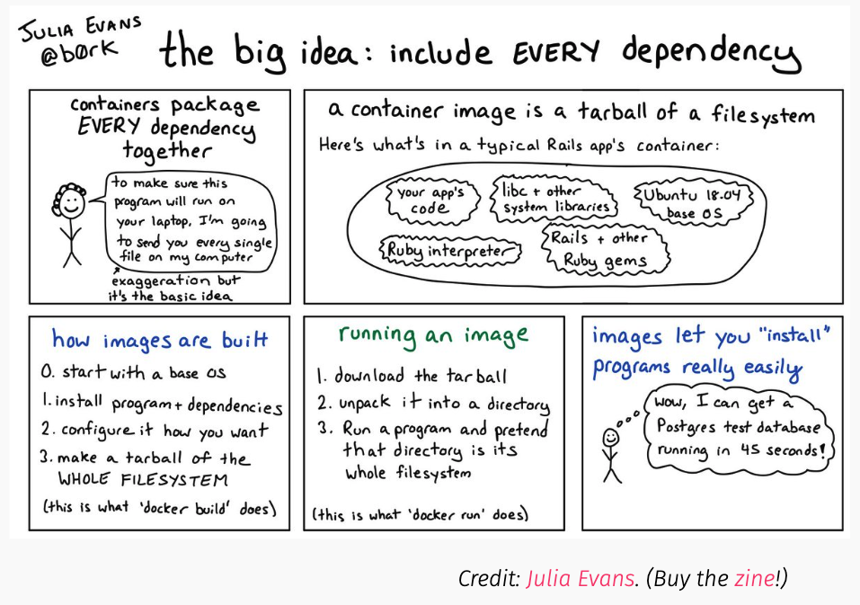

Docker workflow

## Quick terminology

- Dockerfile: “The sheet music.” The list of layers and instructions for building a Docker image.
- Image: “The MP3 file.” This is the tarball.
- Container: “Song playing on my phone.” A container is a running instance of an image.

## Docker workflow

Learning by doing.

1. Create Dockerfile.
2. Build Docker image using Dockerfile.

```bash
sudo docker build --network=host --tag <PROJECT_NAME>:VERSION .
```

3. Run Docker image.

```bash
sudo docker run -it --rm <PROJECT_NAME>:VERSION
```

### Some useful Docker-related commands

```bash
# check cached docker images
sudo docker images

# check docker containers that are running
sudo docker ps

# remove the docker image
sudo docker rmi <IMAGE_NAME>

# remove all dangling images and caches (do it periodically to save space)
sudo docker system prune
```

## Final words 1: Follow the gurus

- [Jonathan Dingel](http://www.jdingel.com/)
- [Grant R. McDermott](https://grantmcdermott.com/)
- [Gentzkow and Shapiro](https://web.stanford.edu/~gentzkow/research/CodeAndData.pdf)

## Final words 2: Become an active googler

Places to resort to

- Stack Overflow
- Quora
- Reddit
- … and Many more!